# HEC_RAS

**Author:** Salvador Navas  
**Reference model:** Muncie, Indiana — 2D unsteady flow (official HEC-RAS tutorial)  
**Source:** [HEC-RAS 2D User Manual Examples](https://www.hec.usace.army.mil/confluence/rasdocs/r2dum)

### HEC-RAS — Automated hydraulic modelling with `pyhydra`

The Muncie example is the standard 2D tutorial that ships with HEC-RAS.  
White River through downtown Muncie, IN; 2D unsteady; combined culverts + bridges;  
inflow from HEC-HMS (upstream BC) + lateral inflows.

Workflow:

1. Project configuration
2. Return-period hydrographs as boundary conditions
3. Modify unsteady flow file (.u##)
4. Modify plan (.p##) and project (.prj) files
5. Run HEC-RAS
6. Extract WSEL results and frequency curve
7. Climate-change delta-factor runs

## 1. 📂 Project configuration

Download the Muncie 2D example from HEC-RAS documentation:  
`Help → Example Data Sets → 2D Unsteady → Muncie_2D`  
or from: https://www.hec.usace.army.mil/confluence/rasdocs/r2dum

Place the project folder at the path below.

```
Project  : Muncie
Path     : /workspace/data/hec_ras/Muncie/
Returns  : [2, 5, 10, 25, 50, 100, 500]
```

## 2. 🌊 Return-period hydrographs (from HEC-HMS)

Load the HEC-HMS peak-flow hydrographs computed in the previous notebook and smooth them for hydraulic stability.

```
7 hydrographs loaded  |  Qp T100 = 124.5 m³/s
```

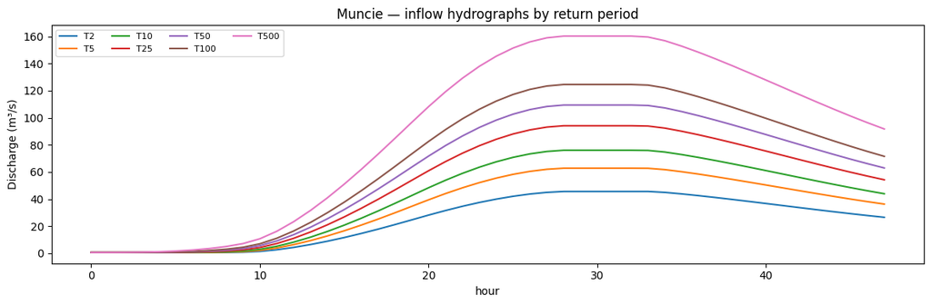

## 3. 🔧 Modify HEC-RAS input files

For each return period:

1. Copy and update the unsteady flow file (`.u##`) with the new hydrograph
2. Update the plan file (`.p##`) to reference the new unsteady file
3. Update the project file (`.prj`) to set the current plan

```
Muncie project not found at /workspace/data/hec_ras/Muncie/
Mount /workspace/data/hec_ras/Muncie/ and re-run.
(File modification skipped — synthetic hydrographs already shown above)
```

## 4. ▶️ Run HEC-RAS

[output not shown]

## 5. 📊 WSEL frequency curve and flood mapping

```
T
2    280.50
5    280.73
10    280.98
25    281.43
50    281.91
100    282.55
500    284.94
Name: Max WSEL (m), dtype: float64
```

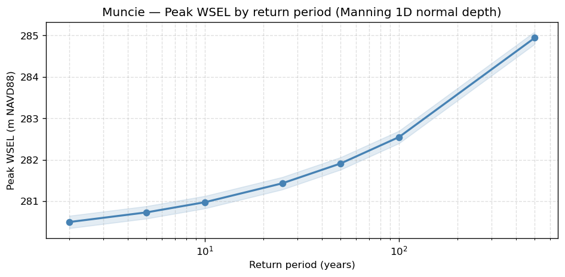

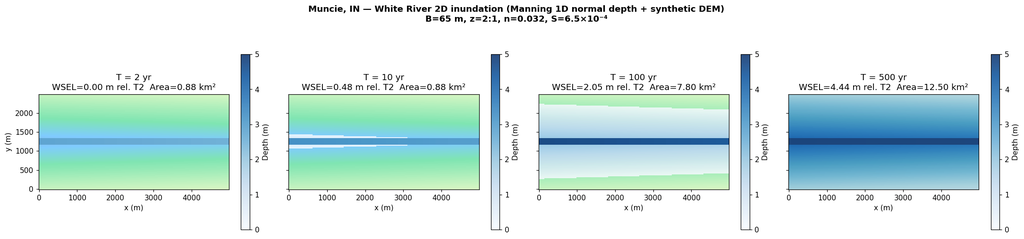

## 6. 🌡️ Climate-change delta runs

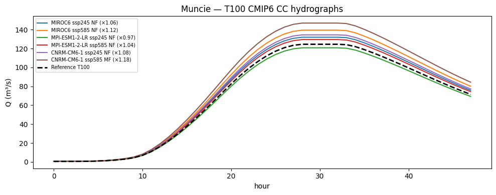